# Time Series: A First Course with Bootstrap Starter

# Lesson 10-5: Relative Entropy Minimization

- We can fit AR(p) models using the sample Yule-Walker equations (Paradigm 10.4.2), or using OLS.
- We can fit MA(q) models using a *spectral factorization*, which is akin to Yule-Walker in that it is a method-of-moments approach.
- Here we focus on the Whittle likelihood and the Gaussian likelihood.

## Remark 10.5.1. Connection to Relative Entropy

- Minimizing asymptotic prediction variance is a method for fitting models.
- If the model has parameters $\underline{\omega}$, then
  $$\widehat{\mathcal{V}}_{\infty} (\underline{\omega}) = { \langle
  g_{\underline{\omega}} \, I \rangle }_0$$
  can be computed for any $\underline{\omega}$, and its minimizer (when unique) is the parameter estimate $\widehat{\underline{\omega}}$.
- Connection to relative entropy: let $\sigma^2 g^{-1}_{\underline{\omega}}$ be the model spectral density. Then
  $$\log \sigma^2 + { \langle \frac{I}{\sigma^2 g_{\underline{\omega}}^{-1}
  } \rangle }_0 =
  \log \sigma^2 + \sigma^{-2} \, \widehat{\mathcal{V}}_{\infty}
  (\underline{\omega})$$
  is the Kullback-Leibler (KL) discrepancy between periodogram and model spectrum. This is called the *Whittle likelihood*.
- KL is minimized with $\widehat{\underline{\omega}}$ and $\widehat{\sigma^2} = \widehat{\mathcal{V}}_{\infty} (\widehat{\underline{\omega}})$.
- We call $\widehat{\mathcal{V}}_{\infty} (\underline{\omega})$ the *Profile Whittle likelihood*.

## Paradigm 10.5.9. The Gaussian Log Likelihood

- We consider the log likelihood of a length $n$ sample from a stationary Gaussian time series. Multiplying by $-2$, we obtain the *Gaussian divergence*:
  $$\mathcal{L} (\underline{\omega}, \sigma^2) =
  n\log (2 \pi) + \log \det \Gamma_n + {( \underline{X} -
  \underline{\mu})}^{\prime} \,
  \Gamma_n^{-1} \, {( \underline{X} - \underline{\mu})}.$$
- Here $\underline{\mu}$ is the mean vector, and equals the mean $\mu$ times a vector of ones.
- And $\underline{\omega}$ is the parameter vector (all the parameters except the input variance $\sigma^2$).
- Note that for AR, MA, and ARMA models, there is a parameter vector $\underline{\omega}$, which together with $\sigma^2$ determines $\gamma (h)$, and thereby $\Gamma_n$.
- To fit a model, we seek to minimize the Gaussian divergence over $\underline{\omega}$ and $\sigma^2$. The resulting minimizers are the Maximum Likelihood Estimators (MLEs) $\widehat{\underline{\omega}}$ and $\widehat{\sigma^2}$.

## Remark 10.5.10. Profile Gaussian Log Likelihood

- For many models, we can factor out $\sigma^2$ from each $\gamma (h)$.
- In such a case, write $\upsilon (h) = \gamma (h) / \sigma^2$, and construct the Toeplitz $\Upsilon_n$ from these $\upsilon (h)$ values.
- Then the divergence becomes
  $$\mathcal{L} (\underline{\omega}, \sigma^2) =
  n\log (2 \pi) + n \log \sigma^2 +
  \log \det \Upsilon_n + \sigma^{-2} {( \underline{X} -
  \underline{\mu})}^{\prime} \,
  \Upsilon_n^{-1} \, {( \underline{X} - \underline{\mu})}.$$
- Use calculus: differentiate with respect to $\sigma^2$, set equal to zero, and solve.
- Get a minimizer $\widehat{\sigma^2}$ that is a function of the still unknown $\underline{\omega}$.
- Plugging this formula back in to the divergence is called *concentration*, and we get a *profile likelihood* $\mathcal{L} (\underline{\omega},\widehat{\sigma^2})$.
- The result is
  $$\begin{align*}
  \widehat{\sigma^2} & = n^{-1} {( \underline{X} -
  \underline{\mu})}^{\prime} \,
  \Upsilon_n^{-1} \, {( \underline{X} - \underline{\mu})} \\
  \mathcal{L} (\underline{\omega},\widehat{\sigma^2}) & =
  n \log (2\pi) + (n+1) \log \widehat{\sigma^2} + \log \det \Upsilon_n.
  \end{align*}$$
- So we can minimize the profile likelihood as a function of $\underline{\omega}$, obtaining $\widehat{\underline{\omega}}$, and then finally get the input variance MLE via plugging into the first formula.
- For large $n$, it can be shown that $n^{-1} \log \det \Upsilon_n \approx 0$, which implies we can dump the last term in the profile likelihood. Then approximately, we can just minimize $\widehat{\sigma^2}$, which is interpretable as a measure of one-step ahead forecast mean squared error.

## Exercise 10.34. Computing the Whittle Likelihood for MA Processes

- We write R code to compute the Whittle likelihood for an MA process.
- So $\underline{\omega} = {[\theta_1, \ldots, \theta_q]}^{\prime}$, and $g(\lambda) = {| 1 + \sum_{j=1}^q \theta_j z^j |}^{-2}$ (see Paradigm 10.4.3).
- First we write a function to compute the periodogram at the Fourier frequencies.

```r
pgram.dft <- function(data)
{
    n <- length(data)
    gamma.hat <- acf(data,lag=n-1,type="covariance",plot=FALSE)$acf[,,1]
    lambda <- seq(-floor(n/2)+1,floor(n/2))*2*pi/n
    pgram <- cos(0*lambda)*gamma.hat[1]
    for(h in 1:(n-1))
    {
        pgram <- pgram + 2*cos(h*lambda)*gamma.hat[h+1]
    }
    pgram <- ts(pgram,start=0,frequency=n)
    return(pgram)
}
```

- Next, we encode the Whittle likelihood for the MA($q$) model.

```r
whittle.ma <- function(theta,sigma,pgram)
{
    n <- length(pgram)
    lambda <- seq(-floor(n/2)+1,floor(n/2))*2*pi/n
    q <- length(theta)
    f.spec <- rep(1,n)
    for(k in 1:q) { f.spec <- f.spec + theta[k]*exp(-1*1i*k*lambda) }
    f.spec <- Mod(f.spec)^2
    lik <- mean(pgram/f.spec)/sigma^2 + log(sigma^2)
    return(lik)
}
```

- Finally, we test this on the Non-Defense Capitalization data.
- We evaluate the Whittle likelihood for the MA(1) model with $\theta_1 = -.466$ and $\sigma^2 = .0053$ (these estimates are based on the spectral factorization method).

```r
ndc <- read.table("Nondefcap.dat")
ndc <- ts(ndc[,2],start=c(1992,3),frequency=12,names= "NewOrders")
pgram <- pgram.dft(diff(ndc))
whittle.ma(-.466,sqrt(.0053),pgram) + log(2*pi)
```

```
## [1] -2.426116
```

## Exercise 10.42. Profile Whittle Likelihood

- We extend Exercise 10.34 to code up the profile Whittle likelihood.

```r
whittleprof.ma <- function(theta,pgram)
{
    n <- length(pgram)
    lambda <- seq(-floor(n/2)+1,floor(n/2))*2*pi/n
    q <- length(theta)
    f.spec <- rep(1,n)
    for(k in 1:q) { f.spec <- f.spec + theta[k]*exp(-1*1i*k*lambda) }
    f.spec <- Mod(f.spec)^2
    lik <- mean(pgram/f.spec)
    return(lik)
}
```

- We test this on a MA(1) simulation with $\theta_1 = .7$, $\sigma^2 = 1$, and $n=100$.

```r
armapq.sim <- function(n,burn,ar.coefs,ma.coefs,innovar)
{
    p <- length(ar.coefs)
    q <- length(ma.coefs)
    z <- rnorm(n+burn+p+q,sd=sqrt(innovar))
    x <- filter(z,c(1,ma.coefs),method="convolution",sides=1)
    x <- x[(q+1):(q+n+burn+p)]
    y <- x[1:p]
    for(t in (p+1):(p+n+burn))
    {
        next.y <- sum(ar.coefs*y[(t-1):(t-p)]) + x[t]
        y <- c(y,next.y)
    }
    y <- y[(p+burn+1):(p+burn+n)]
    return(y)
}

theta <- .7
sigma <- 1
n <- 100
x.sim <- armapq.sim(n,0,NULL,theta,sigma^2)
```

- We compute the Profile Whittle likelihood for a range of $\theta_1$ values, and plot.
- We plot in log scale, for easier visualization.
- This function is lowest at the estimate $\widehat{\theta}_1$. This can be different from the true value $\theta_1 = .7$, due to statistical error.

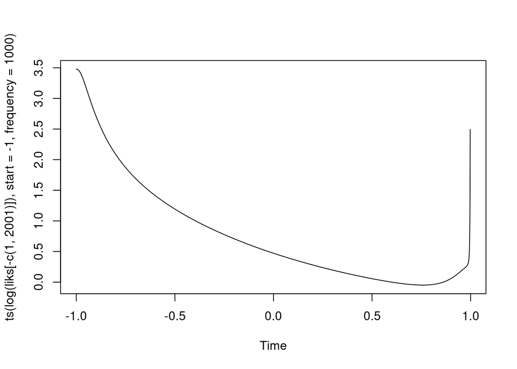

```r
pgram <- pgram.dft(x.sim)
thetas <- seq(-1000,1000)/1000
liks <- NULL
for(theta in thetas)
{
    liks <- c(liks,whittleprof.ma(theta,pgram))
}
plot(ts(log(liks[-c(1,2001)]),start=-1,frequency=1000))
```

```r
thetas[which.min(liks[-c(1,2001)])+1]
```

```
## [1] 0.759
```

## Exercise 10.46. Fitting via the Whittle Likelihood

- We now use the Profile Whitte likelihood to fit an MA(1) model to the Non-Defense Capitalization data.
- We wrap the objective function with an optimizer, using the BFGS method.

```r
pgram <- pgram.dft(diff(ndc))
theta.init <- 0
fit.ma1 <- optim(theta.init,whittleprof.ma,pgram=pgram,method="BFGS")
theta.ope <- fit.ma1$par
sig2.ope <- fit.ma1$value
print(c(theta.ope,sig2.ope))
```

```
## [1] -0.498164132  0.005165085
```